# **Robot vs Senhance-robot**

- compared “senhance-robot” and “robot”
- relationship between variables (age, BMI, ASA, …) and outcomes (operation time, blood loss, …)

# **1 Data Matrix**

|  | AGE_group | Sex | BMI_group | APPROACH | ASA | PRI | TECHNIQUE | Laterality | HERNIA_TYPE | MESH_FIX | ORTIME | CONTIME | Conversion | Transfusion | BLOOD_LOSS | INTRA_COMPS | PORT | FOLLOWUPS | POST_COMPS | Recurrence | Mortality | Reoperation | LOS | LOS_GOV | Post_LOS | Post_LOS_GOV |
| --- | --- | --- | --- | --- | --- | --- | --- | --- | --- | --- | --- | --- | --- | --- | --- | --- | --- | --- | --- | --- | --- | --- | --- | --- | --- | --- |
| 1 | >70 | M | Overweight | 1:robot | ASA1-2 | 1: Primary | 1: TAPP | 1: bilateral | 1: direct | Glue.Suture | 210 | 170 | 0 | 0 | <50 | 0 | 2: non-single port | 2.00 | 0 | 0 | 0 | 0 | 2 | 1 | 2 | 1 |
| 2 | >70 | M | Overweight | 1:robot | ASA1-2 | 1: Primary | 2: TEP | 1: bilateral | 2: indirect | Track | 130 | 90 | 0 | 0 | <50 | 0 | 2: non-single port | 1.00 | 0 | 0 | 0 | 0 | 4 | 3 | 3 | 2 |
| 3 | >70 | M | Overweight | 1:robot | ASA3-4 | 1: Primary | 1: TAPP | 1: bilateral | 2: indirect | Glue.Suture | 180 | 140 | 0 | 0 | <50 | 0 | 2: non-single port | 3.00 | 0 | 0 | 0 | 0 | 3 | 2 | 2 | 1 |
| 4 | 50~70 | M | Normal | 1:robot | ASA1-2 | 1: Primary | 1: TAPP | 1: bilateral | 2: indirect | Glue.Suture | 150 | 110 | 0 | 0 | <50 | 0 | 2: non-single port | 1.00 | 0 | 0 | 0 | 0 | 4 | 3 | 3 | 2 |
| 5 | 50~70 | M | Overweight | 1:robot | ASA1-2 | 2: Recurrent | 1: TAPP | 1: bilateral | 2: indirect | Glue.Suture | 180 | 140 | 0 | 0 | <50 | 0 | 2: non-single port | 1.00 | 0 | 0 | 0 | 0 | 4 | 3 | 4 | 3 |
| 6 | >70 | M | Overweight | 1:robot | ASA3-4 | 3: Incarceration | 1: TAPP | 1: bilateral | 2: indirect | Glue.Suture | 175 | 135 | 0 | 0 | <50 | 0 | 2: non-single port | 2.00 | 0 | 0 | 0 | 0 | 9 | 8 | 8 | 7 |
| 7 | >70 | M | Overweight | 1:robot | ASA3-4 | 1: Primary | 1: TAPP | 1: bilateral | 2: indirect | Glue.Suture | 240 | 200 | 0 | 0 | <50 | 0 | 2: non-single port | 2.00 | 0 | 0 | 0 | 0 | 12 | 11 | 11 | 10 |
| 8 | >70 | M | Normal | 1:robot | ASA1-2 | 1: Primary | 1: TAPP | 1: bilateral | 2: indirect | Glue.Suture | 240 | 200 | 0 | 0 | <50 | 0 | 2: non-single port | 3.00 | 0 | 0 | 0 | 0 | 4 | 3 | 3 | 2 |
| 9 | >70 | M | Overweight | 1:robot | ASA1-2 | 1: Primary | 1: TAPP | 1: bilateral | 1: direct | Glue.Suture | 250 | 210 | 0 | 0 | <50 | 0 | 2: non-single port | 1.00 | 0 | 0 | 0 | 0 | 3 | 2 | 2 | 1 |
| 10 | 50~70 | M | Normal | 1:robot | ASA1-2 | 2: Recurrent | 1: TAPP | 1: bilateral | 2: indirect | Glue.Suture | 145 | 105 | 0 | 0 | <50 | 0 | 2: non-single port | 3.00 | 0 | 0 | 0 | 0 | 3 | 2 | 2 | 1 |

[output cut: 438 more lines]

```
##  AGE_group   Sex          BMI_group               APPROACH       ASA
##  <50  : 88   F: 31   Normal    :262   1:robot         :279   ASA1-2:392
##  >70  :123   M:417   Overweight:186   2:senhance-robot:169   ASA3-4: 56
##  50~70:237
##
##
##
##                PRI        TECHNIQUE           Laterality        HERNIA_TYPE
##  1: Primary      :385   1: TAPP: 83   1: bilateral :340   1: direct   :136
##  2: Recurrent    : 53   2: TEP :365   2: unilateral:108   2: indirect :303
##  3: Incarceration: 10                                     3: femoral  :  7
##                                                           4: obturator:  2
##
##
##         MESH_FIX       ORTIME         CONTIME       Conversion Transfusion
##  Glue.Suture:235   Min.   : 50.0   Min.   :  0.00   0:448      0:448
##  Track      :213   1st Qu.:102.8   1st Qu.: 30.00
##                    Median :129.0   Median : 66.00
##                    Mean   :139.0   Mean   : 72.92
##                    3rd Qu.:165.2   3rd Qu.:101.25
##                    Max.   :383.0   Max.   :335.00
##  BLOOD_LOSS INTRA_COMPS                 PORT       FOLLOWUPS      POST_COMPS
##  <50 :445   0:448       1: single port    :  5   Min.   : 0.200   0:448
##  >=50:  3               2: non-single port:443   1st Qu.: 1.000
##                                                  Median : 3.000
##                                                  Mean   : 4.161
##                                                  3rd Qu.: 4.000
##                                                  Max.   :42.000
##  Recurrence Mortality Reoperation      LOS            LOS_GOV
##  0:448      0:448     0:448       Min.   : 2.000   Min.   : 1.000
##                                   1st Qu.: 3.000   1st Qu.: 2.000
##                                   Median : 3.000   Median : 2.000
##                                   Mean   : 3.299   Mean   : 2.299
##                                   3rd Qu.: 4.000   3rd Qu.: 3.000
##                                   Max.   :12.000   Max.   :11.000
##     Post_LOS        Post_LOS_GOV
##  Min.   : -4.000   Min.   : -5.000
##  1st Qu.:  2.000   1st Qu.:  1.000
##  Median :  2.000   Median :  1.000
##  Mean   :  3.252   Mean   :  2.252
##  3rd Qu.:  3.000   3rd Qu.:  2.000
##  Max.   :367.000   Max.   :366.000
```

## 1.1 Patients’ Baseline

Patient’s Baseline Characteristics

|  | level | 1:robot | 2:senhance-robot | p | test | SMD |
| --- | --- | --- | --- | --- | --- | --- |
| n |  | 279 | 178 |  |  |  |
| AGE_group (%) | <50 | 63 ( 22.6) | 26 ( 14.6) | 0.106 |  | 0.208 |
|  | >70 | 74 ( 26.5) | 50 ( 28.1) |  |  |  |
|  | 50~70 | 142 ( 50.9) | 102 ( 57.3) |  |  |  |
| Sex (%) | F | 24 ( 8.6) | 7 ( 3.9) | 0.081 |  | 0.194 |
|  | M | 255 ( 91.4) | 171 ( 96.1) |  |  |  |
| BMI_group2 (%) | Normal | 160 ( 57.3) | 105 ( 59.0) | 0.080 |  | 0.193 |
|  | Overweight | 119 ( 42.7) | 70 ( 39.3) |  |  |  |
|  | NA | 0 ( 0.0) | 3 ( 1.7) |  |  |  |
| ASA2 (%) | ASA1-2 | 246 ( 88.2) | 155 ( 87.1) | 0.840 |  | 0.033 |
|  | ASA3-4 | 33 ( 11.8) | 23 ( 12.9) |  |  |  |
| PRI (%) | 1: Primary | 227 ( 81.4) | 167 ( 93.8) | 0.001 |  | 0.390 |
|  | 2: Recurrent | 43 ( 15.4) | 10 ( 5.6) |  |  |  |
|  | 3: Incarceration | 9 ( 3.2) | 1 ( 0.6) |  |  |  |
| TECHNIQUE (%) | 1: TAPP | 42 ( 15.1) | 49 ( 27.5) | 0.002 |  | 0.308 |
|  | 2: TEP | 237 ( 84.9) | 129 ( 72.5) |  |  |  |
| Laterality (%) | 1: bilateral | 227 ( 81.4) | 114 ( 64.0) | <0.001 |  | 0.396 |
|  | 2: unilateral | 52 ( 18.6) | 64 ( 36.0) |  |  |  |
| HERNIA_TYPE (%) | 1: direct | 90 ( 32.3) | 46 ( 25.8) | 0.002 |  | 0.397 |
|  | 2: indirect | 180 ( 64.5) | 126 ( 70.8) |  |  |  |
|  | 3: femoral | 7 ( 2.5) | 0 ( 0.0) |  |  |  |
|  | 4: obturator | 2 ( 0.7) | 0 ( 0.0) |  |  |  |
|  | NA | 0 ( 0.0) | 6 ( 3.4) |  |  |  |
| MESH_FIX_2cat (%) | Glue.Suture | 226 ( 81.0) | 10 ( 5.6) | <0.001 |  | 2.344 |
|  | Track | 53 ( 19.0) | 168 ( 94.4) |  |  |  |
| ORTIME (mean (SD)) |  | 155.13 (51.20) | 112.38 (46.86) | <0.001 |  | 0.871 |
| CONTIME (mean (SD)) |  | 89.62 (54.62) | 46.10 (52.91) | <0.001 |  | 0.809 |
| Conversion (%) | 0 | 279 (100.0) | 178 (100.0) | NA |  | <0.001 |
| Transfusion (%) | 0 | 279 (100.0) | 178 (100.0) | NA |  | <0.001 |
| BLOOD_LOSS2 (%) | <50 | 276 ( 98.9) | 178 (100.0) | 0.427 |  | 0.147 |
|  | >=50 | 3 ( 1.1) | 0 ( 0.0) |  |  |  |
| INTRA_COMPS (%) | 0 | 279 (100.0) | 178 (100.0) | NA |  | <0.001 |
| PORT (%) | 1: single port | 5 ( 1.8) | 0 ( 0.0) | 0.182 |  | 0.191 |
|  | 2: non-single port | 274 ( 98.2) | 178 (100.0) |  |  |  |
| FOLLOWUPS (mean (SD)) |  | 5.38 (6.84) | 2.26 (2.18) | <0.001 |  | 0.613 |
| POST_COMPS (%) | 0 | 279 (100.0) | 178 (100.0) | NA |  | <0.001 |
| Recurrence (%) | 0 | 279 (100.0) | 178 (100.0) | NA |  | <0.001 |
| Mortality (%) | 0 | 279 (100.0) | 178 (100.0) | NA |  | <0.001 |
| Reoperation (%) | 0 | 279 (100.0) | 178 (100.0) | NA |  | <0.001 |
| LOS (mean (SD)) |  | 3.41 (1.25) | 3.11 (0.80) | 0.005 |  | 0.283 |
| LOS_GOV (mean (SD)) |  | 2.41 (1.25) | 2.11 (0.80) | 0.005 |  | 0.283 |
| Post_LOS (mean (SD)) |  | 2.60 (1.15) | 4.21 (27.36) | 0.328 |  | 0.083 |
| Post_LOS_GOV (mean (SD)) |  | 1.60 (1.15) | 3.21 (27.36) | 0.328 |  | 0.083 |

## 1.2 BarPlots

### AGE_group

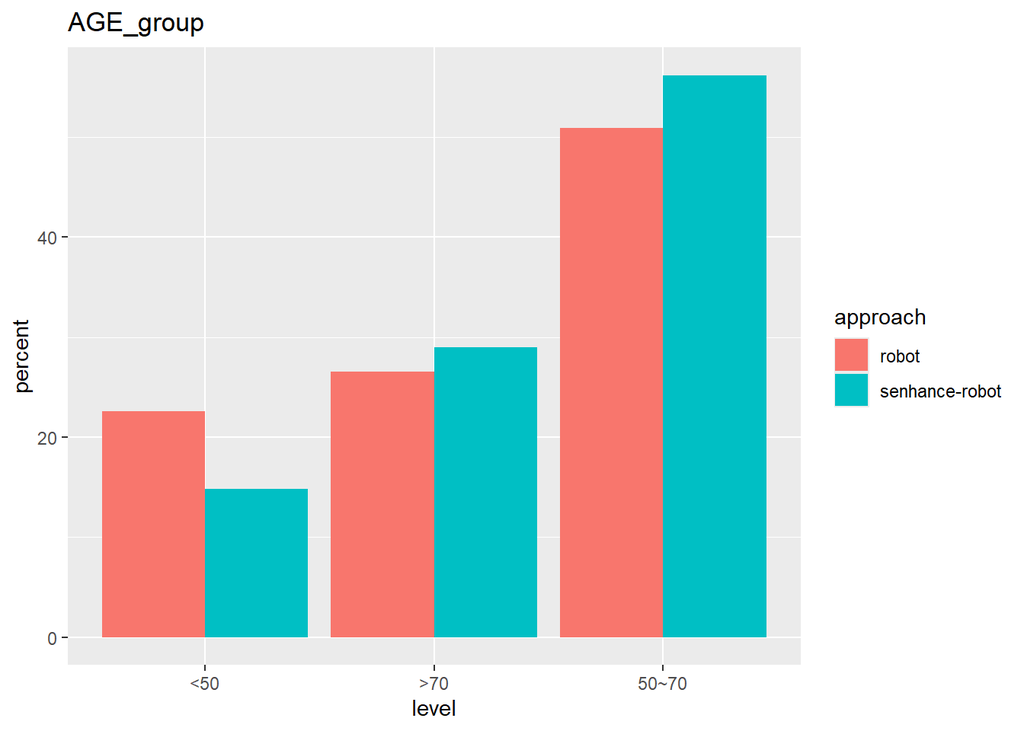

### Sex

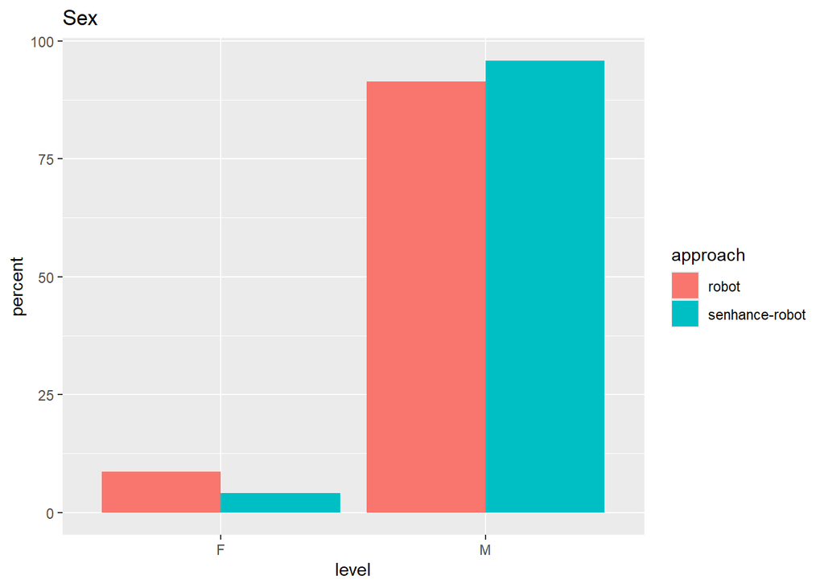

### BMI_group

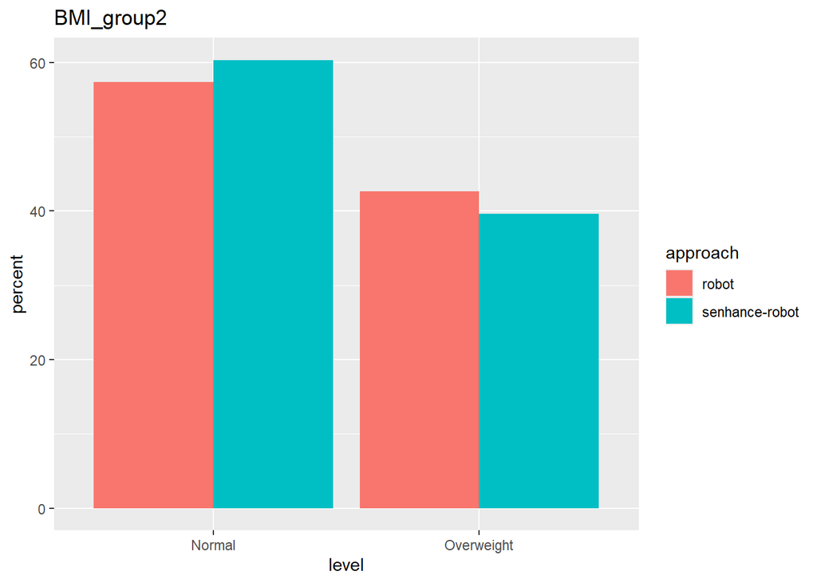

### ASA

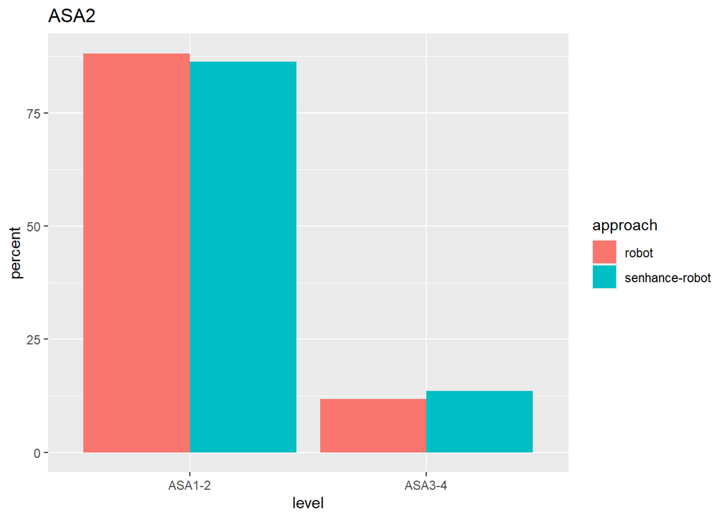

### PRI

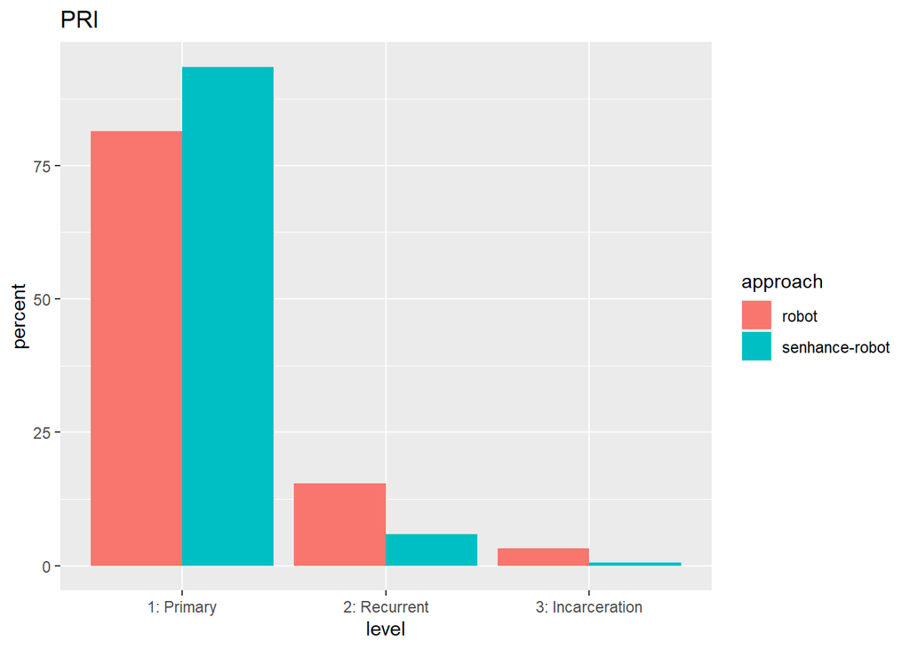

### TECHNIQUE

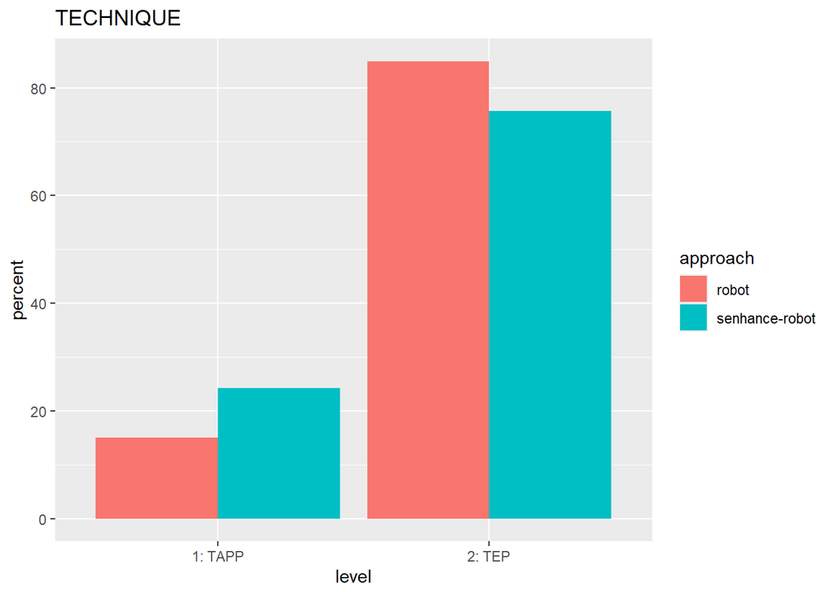

### Laterality

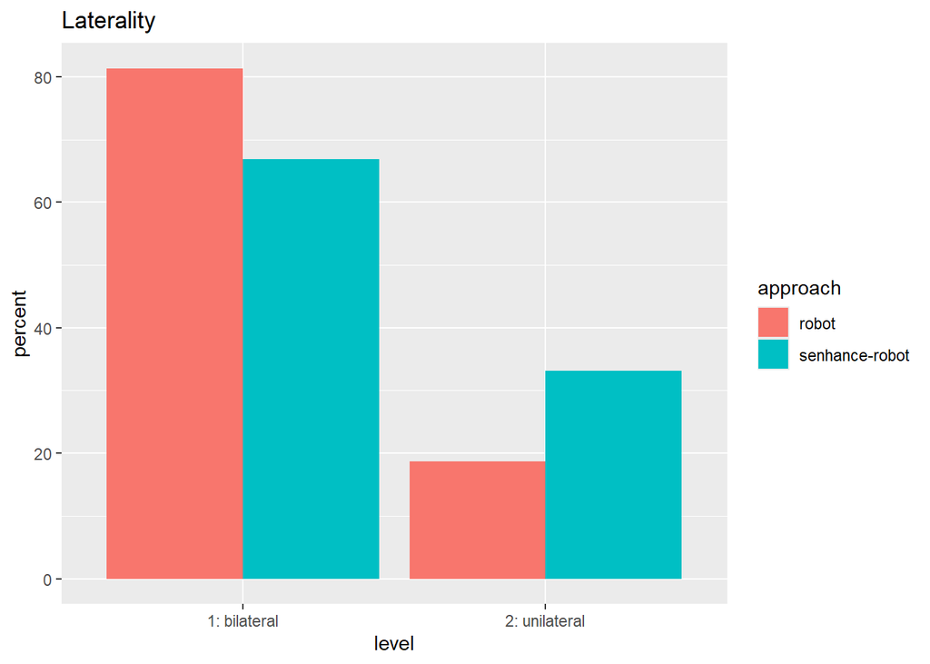

### HERNIA_TYPE

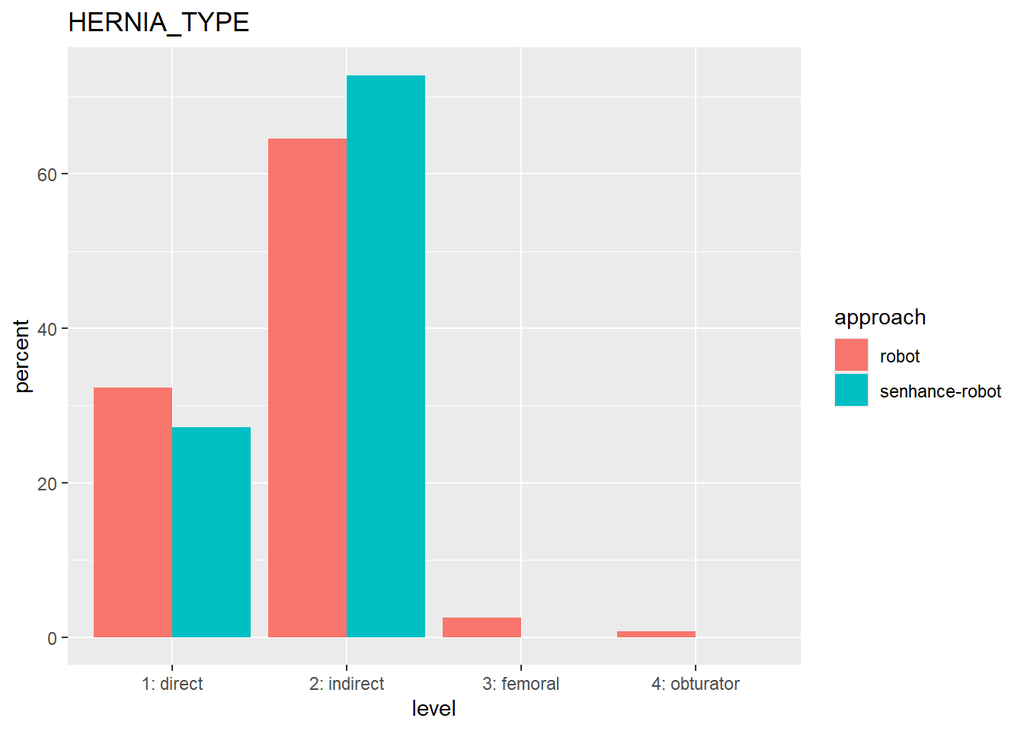

### MESH_FIX_2cat

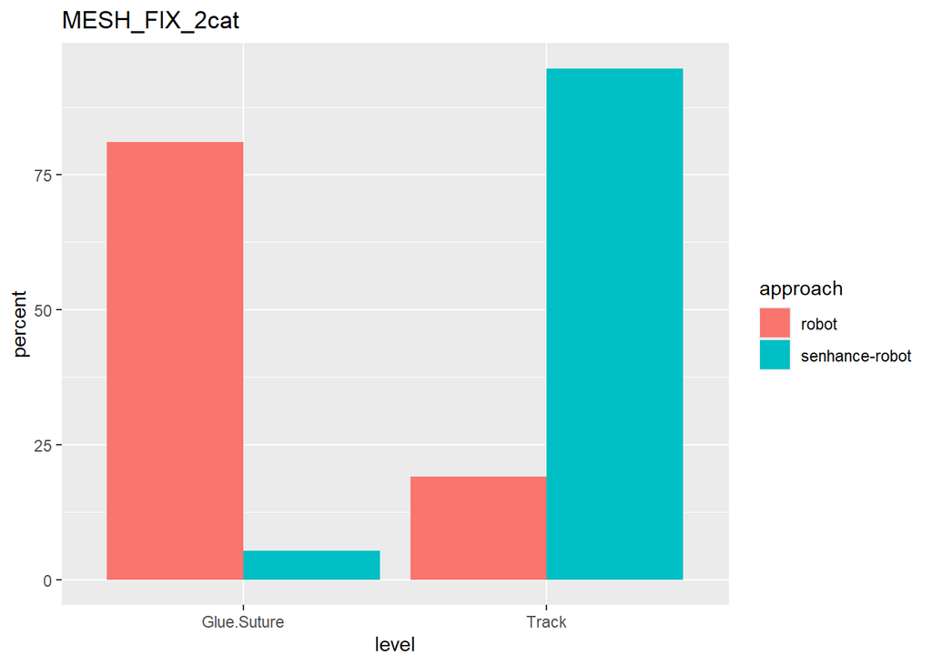

### Conversion

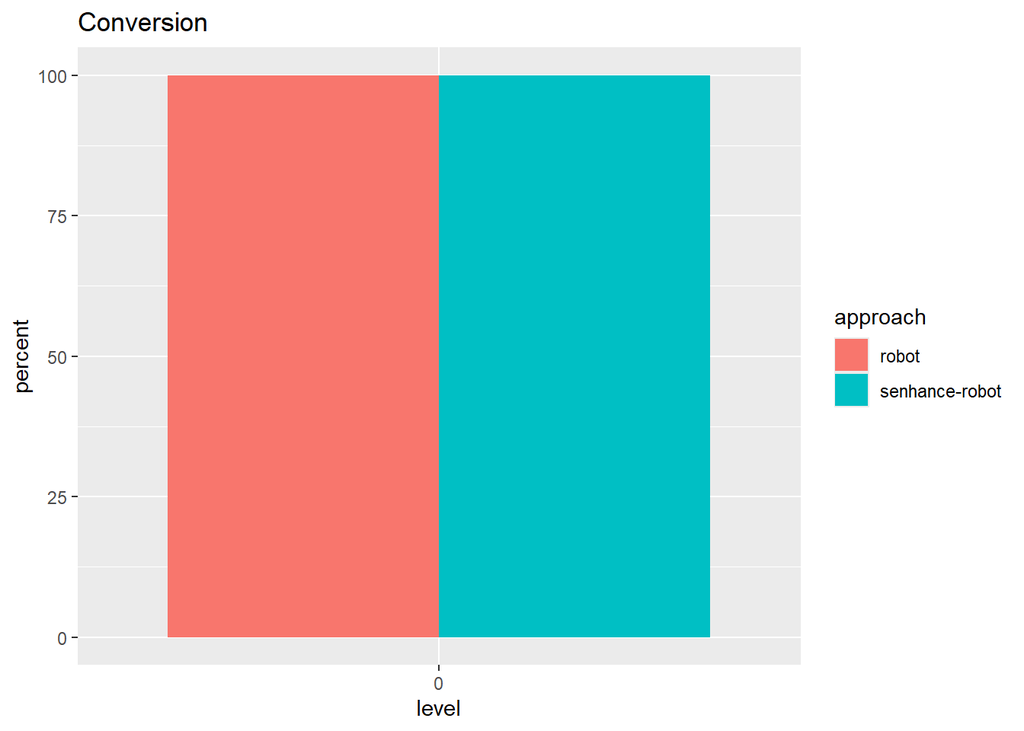

### Transfusion

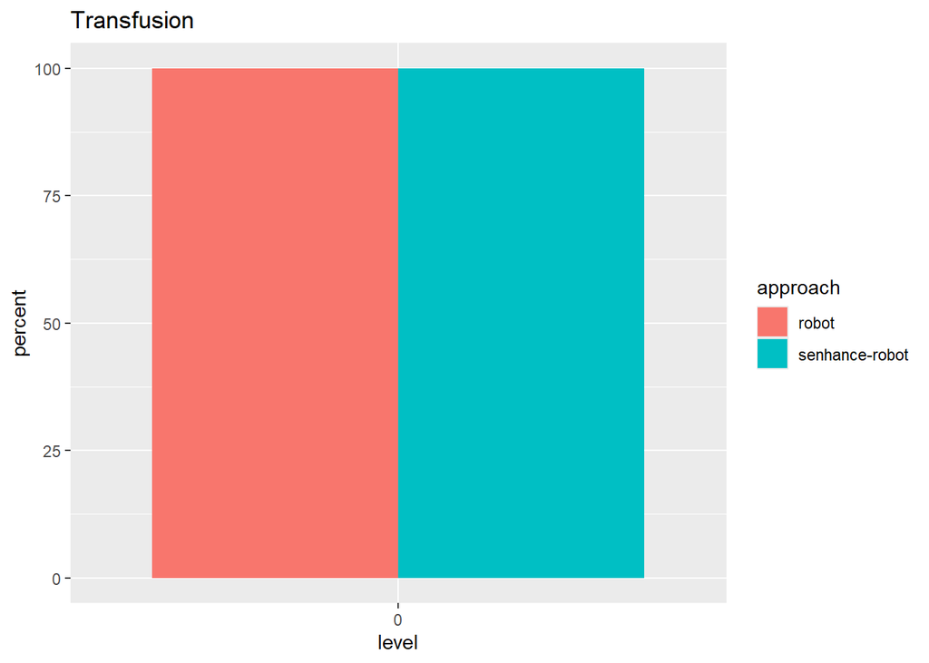

### BLOOD_LOSS

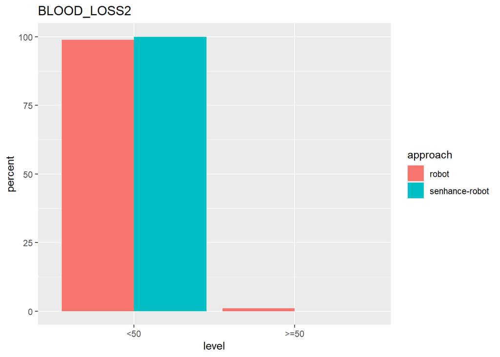

### INTRA_COMPS

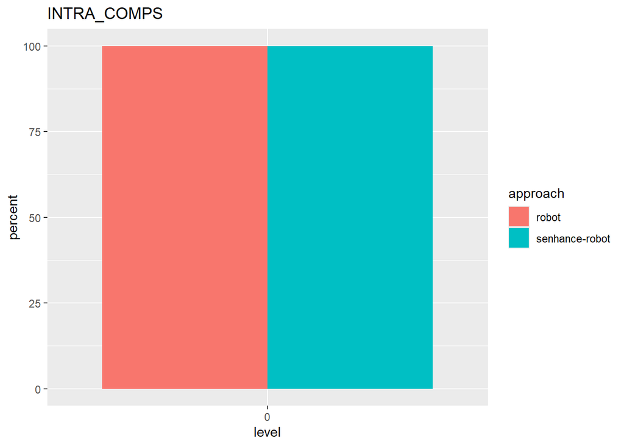

### PORT

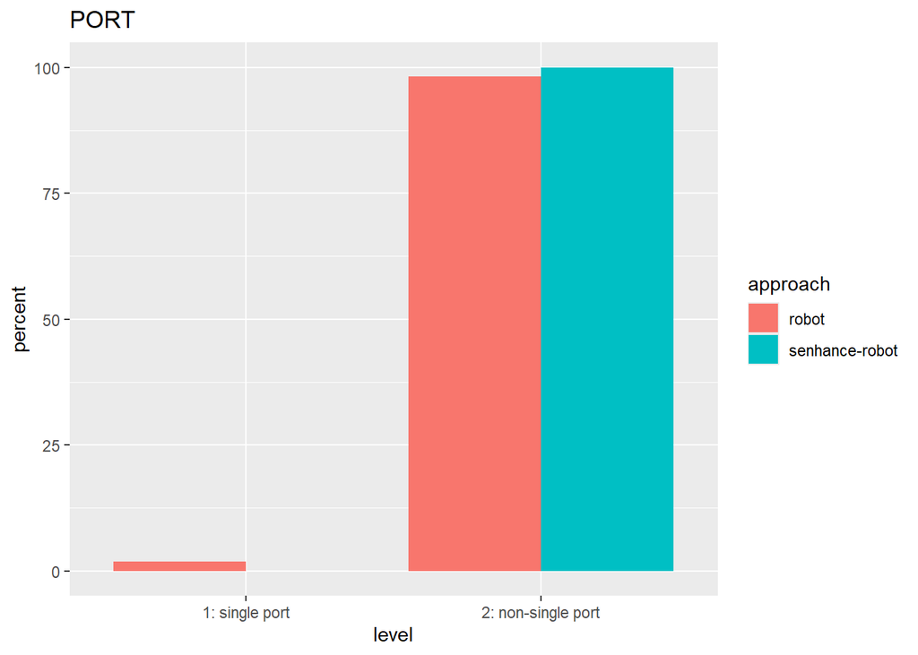

### POST_COMPS

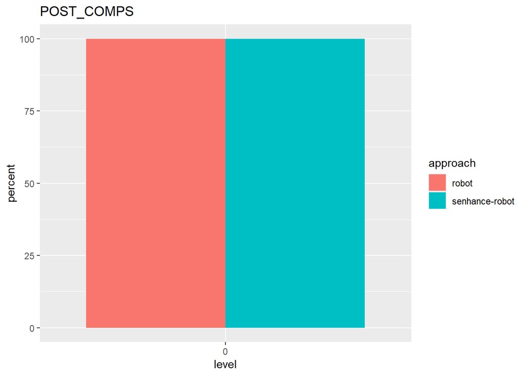

### Recurrence

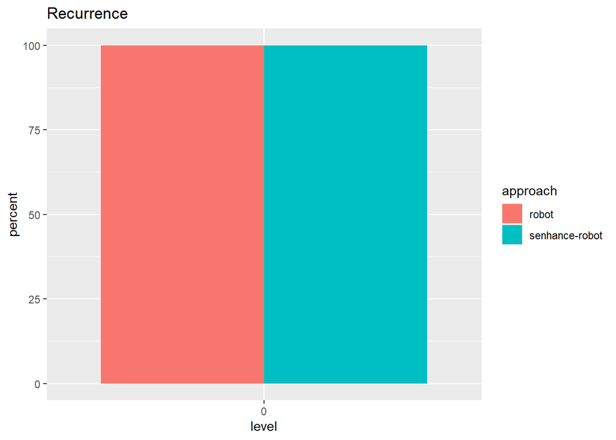

### Mortality

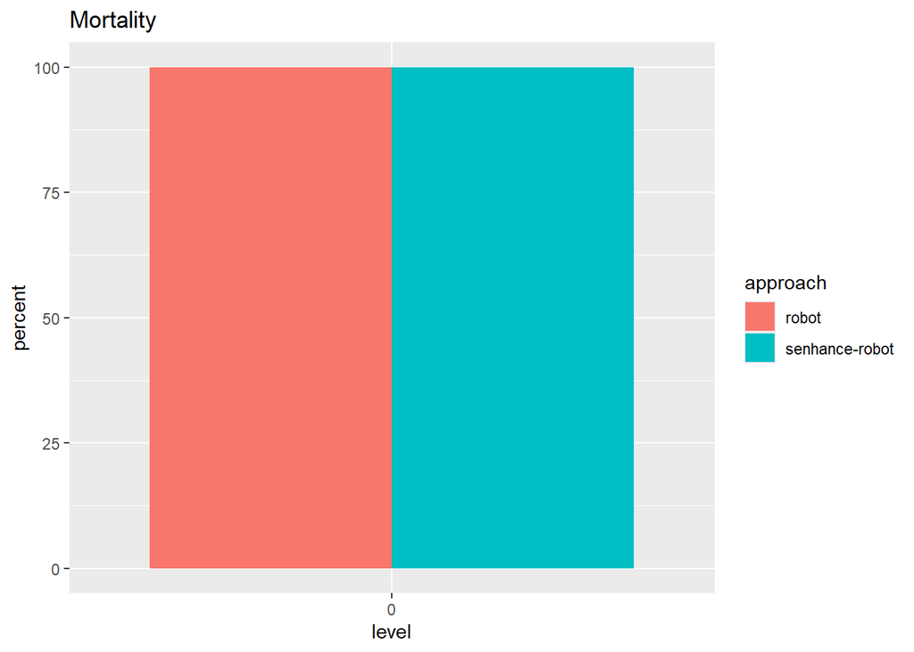

### Reoperation

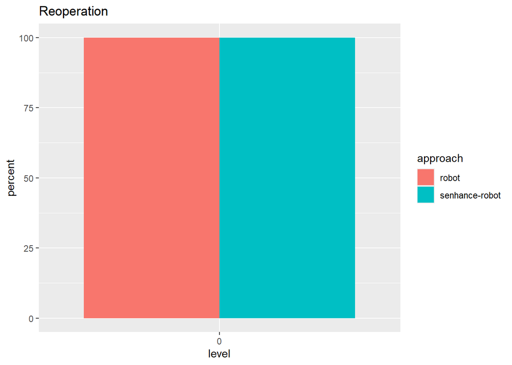

# **2 Weighting**

- [Overlap Weighting](https://www.feinberg.northwestern.edu/sites/firstdailylife/docs/JAMA_Overlap_Weighting_A_Propensity_Score_Method_That_Mimics_Attributes_of_a_Randomized_Clinical_Trial.pdf)

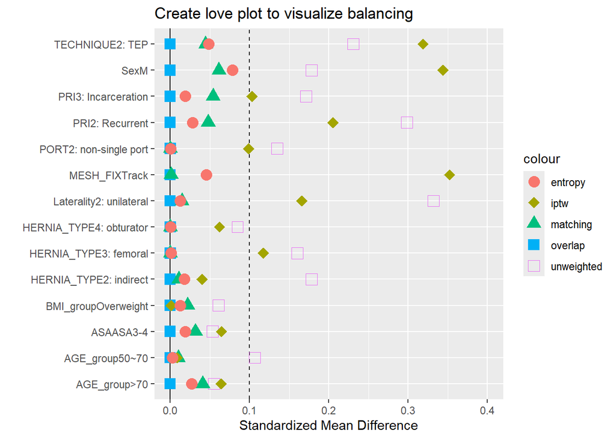

## 2.1 overlap weighting

### after weighting

after overlap weighting

|  | level | 1:robot | 2:senhance-robot | p | test | SMD |
| --- | --- | --- | --- | --- | --- | --- |
| n |  | 279.00 | 169.00 |  |  |  |
| ORTIME (mean (SD)) |  | 150.61 (61.59) | 108.65 (41.19) | <0.001 |  | 0.801 |
| CONTIME (mean (SD)) |  | 65.59 (63.36) | 40.92 (44.45) | 0.005 |  | 0.451 |
| Conversion (%) | 0 | 279.0 (100.0) | 169.0 (100.0) | NA |  | <0.001 |
| Transfusion (%) | 0 | 279.0 (100.0) | 169.0 (100.0) | NA |  | <0.001 |
| FOLLOWUPS (mean (SD)) |  | 12.38 (12.09) | 2.13 (2.10) | <0.001 |  | 1.181 |
| POST_COMPS (%) | 0 | 279.0 (100.0) | 169.0 (100.0) | NA |  | <0.001 |
| Recurrence (%) | 0 | 279.0 (100.0) | 169.0 (100.0) | NA |  | <0.001 |
| Mortality (%) | 0 | 279.0 (100.0) | 169.0 (100.0) | NA |  | <0.001 |
| Reoperation (%) | 0 | 279.0 (100.0) | 169.0 (100.0) | NA |  | <0.001 |
| LOS (mean (SD)) |  | 3.16 (1.36) | 3.16 (0.78) | 0.999 |  | <0.001 |
| LOS_GOV (mean (SD)) |  | 2.16 (1.36) | 2.16 (0.78) | 0.999 |  | <0.001 |
| Post_LOS (mean (SD)) |  | 2.63 (1.09) | 4.76 (30.53) | 0.404 |  | 0.099 |
| Post_LOS_GOV (mean (SD)) |  | 1.63 (1.09) | 3.76 (30.53) | 0.404 |  | 0.099 |

### before weighting

before overlap weighting

|  | level | 1:robot | 2:senhance-robot | p | test | SMD |
| --- | --- | --- | --- | --- | --- | --- |
| n |  | 279 | 169 |  |  |  |
| ORTIME (mean (SD)) |  | 155.13 (51.20) | 112.41 (47.63) | <0.001 |  | 0.864 |
| CONTIME (mean (SD)) |  | 89.62 (54.62) | 45.36 (53.69) | <0.001 |  | 0.817 |
| Conversion (%) | 0 | 279 (100.0) | 169 (100.0) | NA |  | <0.001 |
| Transfusion (%) | 0 | 279 (100.0) | 169 (100.0) | NA |  | <0.001 |
| BLOOD_LOSS2 (%) | <50 | 276 ( 98.9) | 169 (100.0) | 0.450 |  | 0.147 |
|  | >=50 | 3 ( 1.1) | 0 ( 0.0) |  |  |  |
| FOLLOWUPS (mean (SD)) |  | 5.38 (6.84) | 2.15 (2.11) | <0.001 |  | 0.636 |
| POST_COMPS (%) | 0 | 279 (100.0) | 169 (100.0) | NA |  | <0.001 |
| Recurrence (%) | 0 | 279 (100.0) | 169 (100.0) | NA |  | <0.001 |
| Mortality (%) | 0 | 279 (100.0) | 169 (100.0) | NA |  | <0.001 |
| Reoperation (%) | 0 | 279 (100.0) | 169 (100.0) | NA |  | <0.001 |
| LOS (mean (SD)) |  | 3.41 (1.25) | 3.12 (0.82) | 0.007 |  | 0.276 |
| LOS_GOV (mean (SD)) |  | 2.41 (1.25) | 2.12 (0.82) | 0.007 |  | 0.276 |
| Post_LOS (mean (SD)) |  | 2.60 (1.15) | 4.33 (28.08) | 0.306 |  | 0.087 |
| Post_LOS_GOV (mean (SD)) |  | 1.60 (1.15) | 3.33 (28.08) | 0.306 |  | 0.087 |

# **3 Modeling**

Utilized `svyglm()` to analyze and display the relationship between the “Results” and variables. We present the summary and ANOVA table of models including coefficients of the levels for each variable, degree of freedom, etc. On those tables, more `*` comes less p-value. (Signif. codes: `***`$\small< 0.001$, `**` $\small< 0.01$, `*` $\small<0.05$, `.` $\small<0.1$, and otherwise.)

## 3.1 ORTIME

Operation time in minutes. The estimated coefficients for age, BMI, approach (robot and senhance-robot), technique, laterality, and hernia types have low p-values. Clearly, patients over 70 years of age and those with overweight BMI affect operation time. Negative coefficients are observed for approach (senhance-robot), technique (TEP), laterality (unilateral), and sex (male). Focusing on the approach, using the senhance-robot clearly reduces the operation time compared to using the robot.

### Model

```r
summary(ORTIME_model)
```

```
##
## Call:
## svyglm(formula = ORTIME_formula, design = ORTIME_design)
##
## Survey design:
## svydesign(ids = ~1, weights = ~overlap_weight, data = ps_model1_overlap)
##
## Coefficients:
##                          Estimate Std. Error t value Pr(>|t|)
## (Intercept)              189.5313    16.4857  11.497  < 2e-16 ***
## AGE_group>70              34.5014    13.3061   2.593  0.00984 **
## AGE_group50~70             4.0726     7.7776   0.524  0.60081
## SexM                     -24.3092    16.9733  -1.432  0.15281
## BMI_groupOverweight       28.6002     9.6562   2.962  0.00323 **
## APPROACH2:senhance-robot -41.9548     6.7982  -6.171 1.56e-09 ***
## ASAASA3-4                 19.1705    12.6484   1.516  0.13034
## PRI2: Recurrent            4.3215    12.4348   0.348  0.72836
## PRI3: Incarceration        7.9702    14.7011   0.542  0.58799
## TECHNIQUE2: TEP          -53.9774    10.6643  -5.061 6.16e-07 ***
## Laterality2: unilateral  -33.4012     8.3817  -3.985 7.92e-05 ***
## HERNIA_TYPE2: indirect    -0.8636    10.1022  -0.085  0.93191
## HERNIA_TYPE3: femoral     66.3621    23.9155   2.775  0.00576 **
## HERNIA_TYPE4: obturator   22.2489    17.5988   1.264  0.20683
## MESH_FIXTrack              8.8676     7.7480   1.144  0.25305
## ---
## Signif. codes:  0 '***' 0.001 '**' 0.01 '*' 0.05 '.' 0.1 ' ' 1
##
## (Dispersion parameter for gaussian family taken to be 2081.926)
##
## Number of Fisher Scoring iterations: 2
```

### ANOVA Table

```r
anova(ORTIME_model)
```

```
## Anova table:  (Rao-Scott LRT)
## svyglm(formula = ORTIME ~ AGE_group, design = ORTIME_design)
##                  stats       DEff         df ddf         p
## AGE_group    74269.557  11975.200      2.000 445 0.0576294 .
## Sex          81398.658  20315.500      1.000 444 0.0475169 *
## BMI_group    75824.977  11523.600      1.000 443 0.0111699 *
## APPROACH    185257.540   6530.100      1.000 442 1.754e-07 ***
## ASA          20280.346   8612.900      1.000 441 0.1282283
## PRI           9326.690   5112.500      2.000 439 0.3528826
## TECHNIQUE    69845.483   8186.900      1.000 438 0.0038842 **
## Laterality   74745.138   4926.400      1.000 437 0.0001222 ***
## HERNIA_TYPE     45.733   2859.200      3.000 434 0.9379246
## MESH_FIX      3298.356   2518.100      1.000 433 0.2552454
## ---
## Signif. codes:  0 '***' 0.001 '**' 0.01 '*' 0.05 '.' 0.1 ' ' 1
```

## 3.2 CONTIME

Console time from surgeons could be recorded and compared with the data from ISI for analysis. The results are similar to those for operation time.

### Model

```r
summary(CONTIME_model)
```

```
##
## Call:
## svyglm(formula = CONTIME_formula, design = CONTIME_design)
##
## Survey design:
## svydesign(ids = ~1, weights = ~overlap_weight, data = ps_model1_overlap)
##
## Coefficients:
##                           Estimate Std. Error t value Pr(>|t|)
## (Intercept)              155.33159   24.30886   6.390 4.29e-10 ***
## AGE_group>70              25.40615   13.17895   1.928 0.054536 .
## AGE_group50~70             0.03777   10.51555   0.004 0.997136
## SexM                     -44.82355   24.10486  -1.860 0.063631 .
## BMI_groupOverweight        6.06312    5.97985   1.014 0.311184
## APPROACH2:senhance-robot -24.66737    6.40552  -3.851 0.000135 ***
## ASAASA3-4                 14.07091   12.06081   1.167 0.243989
## PRI2: Recurrent          -32.74805   11.55631  -2.834 0.004815 **
## PRI3: Incarceration      -50.77270   20.75851  -2.446 0.014847 *
## TECHNIQUE2: TEP          -54.37352   14.08870  -3.859 0.000131 ***
## Laterality2: unilateral  -15.60789   10.94675  -1.426 0.154646
## HERNIA_TYPE2: indirect    10.37950    6.65320   1.560 0.119472
## HERNIA_TYPE3: femoral     10.62308   17.07066   0.622 0.534072
## HERNIA_TYPE4: obturator  -22.96239   26.48479  -0.867 0.386421
## MESH_FIXTrack            -22.54200   11.28642  -1.997 0.046421 *
## ---
## Signif. codes:  0 '***' 0.001 '**' 0.01 '*' 0.05 '.' 0.1 ' ' 1
##
## (Dispersion parameter for gaussian family taken to be 1852.203)
##
## Number of Fisher Scoring iterations: 2
```

### ANOVA Table

```r
anova(CONTIME_model)
```

```
## Anova table:  (Rao-Scott LRT)
## svyglm(formula = CONTIME ~ AGE_group, design = CONTIME_design)
##                 stats      DEff        df ddf         p
## AGE_group    67944.99  12592.20      2.00 445 0.0706705 .
## Sex         204422.40  21124.00      1.00 444 0.0021095 **
## BMI_group      247.81   5859.40      1.00 443 0.8306389
## APPROACH     64041.07   6434.20      1.00 442 0.0018237 **
## ASA          24058.60  10915.10      1.00 441 0.1410044
## PRI          36298.13   1711.10      2.00 439 0.0006433 ***
## TECHNIQUE   245507.51   7871.90      1.00 438 4.529e-08 ***
## Laterality   11622.22   7538.40      1.00 437 0.2175297
## HERNIA_TYPE   8476.73   1248.20      3.00 434 0.1357952
## MESH_FIX     21314.21   5343.10      1.00 433 0.0480227 *
## ---
## Signif. codes:  0 '***' 0.001 '**' 0.01 '*' 0.05 '.' 0.1 ' ' 1
```

## 3.3 BLOOD_LOSS

Blood loss is group by $<50$ and $\geq 50$ (ml), but the number of patients with blood loss over 50 ml decreases to zero even after overlap weighting.

### Model

```r
summary(BLOOD_LOSS_model)
```

```
##
## Call:
## svyglm(formula = BLOOD_LOSS_formula, design = BLOOD_LOSS_design)
##
## Survey design:
## svydesign(ids = ~1, weights = ~overlap_weight, data = ps_model1_overlap)
##
## Coefficients:
##                           Estimate Std. Error t value Pr(>|t|)
## (Intercept)               1.016109   0.021491  47.281   <2e-16 ***
## AGE_group>70              0.057933   0.043920   1.319    0.188
## AGE_group50~70           -0.008117   0.009640  -0.842    0.400
## SexM                      0.032905   0.025530   1.289    0.198
## BMI_groupOverweight       0.029034   0.034399   0.844    0.399
## APPROACH2:senhance-robot -0.027139   0.018953  -1.432    0.153
## ASAASA3-4                 0.025439   0.048943   0.520    0.603
## PRI2: Recurrent          -0.040345   0.028495  -1.416    0.158
## PRI3: Incarceration      -0.051410   0.040268  -1.277    0.202
## TECHNIQUE2: TEP          -0.028726   0.021122  -1.360    0.175
## Laterality2: unilateral  -0.003563   0.022574  -0.158    0.875
## HERNIA_TYPE2: indirect   -0.032290   0.034436  -0.938    0.349
## HERNIA_TYPE3: femoral    -0.009626   0.019367  -0.497    0.619
## HERNIA_TYPE4: obturator  -0.085776   0.059898  -1.432    0.153
## MESH_FIXTrack             0.007433   0.015466   0.481    0.631
## ---
## Signif. codes:  0 '***' 0.001 '**' 0.01 '*' 0.05 '.' 0.1 ' ' 1
##
## (Dispersion parameter for gaussian family taken to be 0.01510069)
##
## Number of Fisher Scoring iterations: 2
```

### ANOVA Table

```r
anova(BLOOD_LOSS_model)
```

```
## Anova table:  (Rao-Scott LRT)
## svyglm(formula = as.numeric(BLOOD_LOSS) ~ AGE_group, design = BLOOD_LOSS_design)
##              stats      DEff        df ddf      p
## AGE_group   0.3534 0.0897980 2.0000000 445 0.1641
## Sex         0.0217 0.0140560 1.0000000 444 0.2173
## BMI_group   0.0680 0.1044180 1.0000000 443 0.4198
## APPROACH    0.0775 0.0389370 1.0000000 442 0.1616
## ASA         0.0150 0.1233720 1.0000000 441 0.7210
## PRI         0.0375 0.0120370 2.0000000 439 0.2080
## TECHNIQUE   0.0303 0.0548780 1.0000000 438 0.4568
## Laterality  0.0014 0.0383340 1.0000000 437 0.8414
## HERNIA_TYPE 0.0867 0.0327620 3.0000000 434 0.3490
## MESH_FIX    0.0023 0.0100330 1.0000000 433 0.6263
```

## 3.4 FOLLOWUPS

### Model

```r
summary(FOLLOWUPS_model)
```

```
##
## Call:
## svyglm(formula = FOLLOWUPS_formula, design = FOLLOWUPS_design)
##
## Survey design:
## svydesign(ids = ~1, weights = ~overlap_weight, data = ps_model1_overlap)
##
## Coefficients:
##                           Estimate Std. Error t value Pr(>|t|)
## (Intercept)               14.13746    3.41529   4.139 4.19e-05 ***
## AGE_group>70              -4.61615    3.28217  -1.406   0.1603
## AGE_group50~70            -2.70669    2.99765  -0.903   0.3671
## SexM                       0.14930    2.55774   0.058   0.9535
## BMI_groupOverweight       -3.75983    1.86635  -2.015   0.0446 *
## APPROACH2:senhance-robot -10.24826    1.54789  -6.621 1.06e-10 ***
## ASAASA3-4                  3.07512    3.12923   0.983   0.3263
## PRI2: Recurrent            0.08524    2.57500   0.033   0.9736
## PRI3: Incarceration        2.97861    2.61549   1.139   0.2554
## TECHNIQUE2: TEP            0.86251    2.02276   0.426   0.6700
## Laterality2: unilateral   -1.62992    1.68354  -0.968   0.3335
## HERNIA_TYPE2: indirect    -3.04217    2.02305  -1.504   0.1334
## HERNIA_TYPE3: femoral    -11.28149    2.65640  -4.247 2.65e-05 ***
## HERNIA_TYPE4: obturator   -4.81373    2.80758  -1.715   0.0871 .
## MESH_FIXTrack              4.90739    1.98404   2.473   0.0138 *
## ---
## Signif. codes:  0 '***' 0.001 '**' 0.01 '*' 0.05 '.' 0.1 ' ' 1
##
## (Dispersion parameter for gaussian family taken to be 80.35916)
##
## Number of Fisher Scoring iterations: 2
```

### ANOVA Table

```r
anova(FOLLOWUPS_model)
```

```
## Anova table:  (Rao-Scott LRT)
## svyglm(formula = FOLLOWUPS ~ AGE_group, design = FOLLOWUPS_design)
##                 stats      DEff        df ddf         p
## AGE_group     465.447   587.010     2.000 445  0.666275
## Sex            22.811   200.750     1.000 444  0.729851
## BMI_group    1298.462   443.740     1.000 443  0.090144 .
## APPROACH    11053.842   249.330     1.000 442 9.136e-11 ***
## ASA            96.994   457.330     1.000 441  0.640309
## PRI            68.821   129.760     2.000 439  0.652451
## TECHNIQUE    1480.253   209.640     1.000 438  0.008591 **
## Laterality    283.253   166.480     1.000 437  0.195409
## HERNIA_TYPE   740.027   111.950     3.000 434  0.141085
## MESH_FIX     1010.150   165.110     1.000 433  0.014417 *
## ---
## Signif. codes:  0 '***' 0.001 '**' 0.01 '*' 0.05 '.' 0.1 ' ' 1
```

## 3.5 Post_LOS

The days between surgery and discharged, and we then drop the outlier.

### Model

```r
summary(Post_LOS_model)
```

```
##
## Call:
## svyglm(formula = Post_LOS_formula, design = Post_LOS_design)
##
## Survey design:
## svydesign(ids = ~1, weights = ~overlap_weight, data = ps_model_overlap_postLOS)
##
## Coefficients:
##                           Estimate Std. Error t value Pr(>|t|)
## (Intercept)               2.769342   0.322349   8.591  < 2e-16 ***
## AGE_group>70              0.898250   0.253491   3.544 0.000438 ***
## AGE_group50~70            0.264599   0.149880   1.765 0.078205 .
## SexM                     -0.285914   0.244608  -1.169 0.243104
## BMI_groupOverweight       0.156343   0.148771   1.051 0.293895
## APPROACH2:senhance-robot -0.384572   0.116912  -3.289 0.001087 **
## ASAASA3-4                -0.060181   0.241655  -0.249 0.803450
## PRI2: Recurrent          -0.018338   0.236943  -0.077 0.938347
## PRI3: Incarceration      -0.001536   0.262144  -0.006 0.995329
## TECHNIQUE2: TEP          -0.852740   0.239675  -3.558 0.000415 ***
## Laterality2: unilateral   0.023078   0.245686   0.094 0.925207
## HERNIA_TYPE2: indirect    0.164973   0.155242   1.063 0.288522
## HERNIA_TYPE3: femoral     0.110431   0.364519   0.303 0.762075
## HERNIA_TYPE4: obturator   0.555645   0.908912   0.611 0.541305
## MESH_FIXTrack             0.244160   0.155968   1.565 0.118212
## ---
## Signif. codes:  0 '***' 0.001 '**' 0.01 '*' 0.05 '.' 0.1 ' ' 1
##
## (Dispersion parameter for gaussian family taken to be 0.692914)
##
## Number of Fisher Scoring iterations: 2
```

### ANOVA Table

```r
anova(Post_LOS_model)
```

```
## Anova table:  (Rao-Scott LRT)
## svyglm(formula = Post_LOS ~ AGE_group, design = Post_LOS_design)
##               stats       DEff         df ddf         p
## AGE_group   38.6129 2.9654e+00 2.0000e+00 442  0.003922 **
## Sex         19.9470 2.0404e+00 1.0000e+00 441  0.002003 **
## BMI_group    2.6570 2.4481e+00 1.0000e+00 440  0.299749
## APPROACH    15.3446 1.7282e+00 1.0000e+00 439  0.003226 **
## ASA          0.0003 3.2204e+00 1.0000e+00 438  0.991560
## PRI          2.0595 2.6181e+00 2.0000e+00 436  0.600389
## TECHNIQUE   35.9547 2.1456e+00 1.0000e+00 435 5.471e-05 ***
## Laterality   0.0014 4.1194e+00 1.0000e+00 434  0.983868
## HERNIA_TYPE  2.3592 6.9440e-01 3.0000e+00 431  0.289660
## MESH_FIX     2.4941 1.0177e+00 1.0000e+00 430  0.120772
## ---
## Signif. codes:  0 '***' 0.001 '**' 0.01 '*' 0.05 '.' 0.1 ' ' 1
```

### Outlier

Negative($\leq 0$) and large($>200$) value os not allow for Post_LOS.

```r
ROBOT_ORG%>%filter(Post_LOS<=0 | Post_LOS>200)
```

| PatientID | Age | AGE_group | Sex | HEIGHT | WEIGHT | BMI | BMI_group | BMI_group2 | Admission.date | Surgery.date | Discharge.date | APPROACH | ASA | ASA2 | PRI | SIZE_PRE | TECHNIQUE | Laterality | HERNIA_TYPE | MESH_WEIGHT | MESH_FIX | MESH_FIX_2cat | ORTIME | CONTIME | Conversion | Transfusion | BLOOD_LOSS | BLOOD_LOSS2 | INTRA_COMPS | … |
| --- | --- | --- | --- | --- | --- | --- | --- | --- | --- | --- | --- | --- | --- | --- | --- | --- | --- | --- | --- | --- | --- | --- | --- | --- | --- | --- | --- | --- | --- | --- |
| 202 | 72 | >70 | M | 153 | 68.0 | 29.0 | Overweight | Overweight | 2018-04-18 | 2018-04-21 | 2018-04-20 | 1:robot | ASA 1 | ASA1-2 | 3: Incarceration | x: not investigated | 2: TEP | 2: unilateral | 2: indirect | NA | 4: suture | Glue.Suture | 265 | 162 | 0 | 0 | 2. 20-50 mL | <50 | 0 | … |
| Y410666 | 55 | 50~70 | M | 165 | 78.0 | 28.7 | Overweight | Overweight | 2020-01-16 | 2019-01-16 | 2020-01-17 | 2:senhance-robot | ASA 2 | ASA1-2 | 1: Primary | NA | 2: TEP | 1: bilateral | 2: indirect | NA | 1: absorbable tack | Track | 114 | 44 | 0 | 0 | Minimum | <50 | 0 | … |
| Y089316 | 71 | >70 | M | 170 | 80.2 | 27.8 | Overweight | Overweight | 2021-10-17 | 2021-10-26 | 2021-10-21 | 2:senhance-robot | ASA 2 | ASA1-2 | 1: Primary | NA | 2: TEP | 1: bilateral | 2: indirect | NA | 1: absorbable tack | Track | 140 | 13 | 0 | 0 | Minimum | <50 | 0 | … |

## 3.6 LOS

“LOS” is the number of days between admission and discharge, and “Post_LOS” is the number of days between surgery and discharge. Therefore, they differ in only one aspect in the model summary: the variable “APPROACH” does not affect “LOS.”

### Model

```r
summary(LOS_model)
```

```
##
## Call:
## svyglm(formula = LOS_formula, design = LOS_design)
##
## Survey design:
## svydesign(ids = ~1, weights = ~overlap_weight, data = ps_model1_overlap)
##
## Coefficients:
##                            Estimate Std. Error t value Pr(>|t|)
## (Intercept)               3.7377792  0.3572829  10.462  < 2e-16 ***
## AGE_group>70              0.9311133  0.2689239   3.462 0.000589 ***
## AGE_group50~70            0.1759594  0.1724445   1.020 0.308117
## SexM                     -0.4292888  0.2795770  -1.535 0.125393
## BMI_groupOverweight       0.2379497  0.1758118   1.353 0.176623
## APPROACH2:senhance-robot  0.0002415  0.1406651   0.002 0.998631
## ASAASA3-4                 0.1648086  0.2601419   0.634 0.526720
## PRI2: Recurrent           0.1237120  0.2326602   0.532 0.595187
## PRI3: Incarceration      -0.1035206  0.3165485  -0.327 0.743804
## TECHNIQUE2: TEP          -1.0535033  0.2221880  -4.741 2.88e-06 ***
## Laterality2: unilateral   0.0378191  0.2533315   0.149 0.881397
## HERNIA_TYPE2: indirect    0.1883987  0.1949048   0.967 0.334274
## HERNIA_TYPE3: femoral    -0.1734274  0.3291467  -0.527 0.598533
## HERNIA_TYPE4: obturator   0.5533874  0.9364252   0.591 0.554857
## MESH_FIXTrack            -0.0111307  0.1732705  -0.064 0.948809
## ---
## Signif. codes:  0 '***' 0.001 '**' 0.01 '*' 0.05 '.' 0.1 ' ' 1
##
## (Dispersion parameter for gaussian family taken to be 0.9504672)
##
## Number of Fisher Scoring iterations: 2
```

### ANOVA Table

```r
anova(LOS_model)
```

```
## Anova table:  (Rao-Scott LRT)
## svyglm(formula = LOS ~ AGE_group, design = LOS_design)
##               stats       DEff         df ddf         p
## AGE_group   57.5109 4.2800e+00 2.0000e+00 445 0.0030173 **
## Sex         35.3105 2.2876e+00 1.0000e+00 444 0.0001066 ***
## BMI_group    5.2028 3.5125e+00 1.0000e+00 443 0.2266767
## APPROACH     0.0000 2.6394e+00 1.0000e+00 442 0.9986555
## ASA          3.3074 4.2391e+00 1.0000e+00 441 0.3779613
## PRI          4.5219 2.7402e+00 2.0000e+00 439 0.4016559
## TECHNIQUE   80.0732 2.4750e+00 1.0000e+00 438 2.592e-08 ***
## Laterality   0.1109 4.2384e+00 1.0000e+00 437 0.8655157
## HERNIA_TYPE  2.9664 1.0597e+00 3.0000e+00 434 0.3357319
## MESH_FIX     0.0052 1.2593e+00 1.0000e+00 433 0.9452447
## ---
## Signif. codes:  0 '***' 0.001 '**' 0.01 '*' 0.05 '.' 0.1 ' ' 1
```

# **4 Results**

## 4.1 outcome after weighting

### overlap weighted

|  | level | 1:robot | 2:senhance-robot | p | test | SMD |
| --- | --- | --- | --- | --- | --- | --- |
| n |  | 279.00 | 169.00 |  |  |  |
| ORTIME (mean (SD)) |  | 150.61 (61.59) | 108.65 (41.19) | <0.001 |  | 0.801 |
| CONTIME (mean (SD)) |  | 65.59 (63.36) | 40.92 (44.45) | 0.005 |  | 0.451 |
| Conversion (%) | 0 | 279.0 (100.0) | 169.0 (100.0) | NA |  | <0.001 |
| Transfusion (%) | 0 | 279.0 (100.0) | 169.0 (100.0) | NA |  | <0.001 |
| FOLLOWUPS (mean (SD)) |  | 12.38 (12.09) | 2.13 (2.10) | <0.001 |  | 1.181 |
| POST_COMPS (%) | 0 | 279.0 (100.0) | 169.0 (100.0) | NA |  | <0.001 |
| Recurrence (%) | 0 | 279.0 (100.0) | 169.0 (100.0) | NA |  | <0.001 |
| Mortality (%) | 0 | 279.0 (100.0) | 169.0 (100.0) | NA |  | <0.001 |
| Reoperation (%) | 0 | 279.0 (100.0) | 169.0 (100.0) | NA |  | <0.001 |
| LOS (mean (SD)) |  | 3.16 (1.36) | 3.16 (0.78) | 0.999 |  | <0.001 |
| LOS_GOV (mean (SD)) |  | 2.16 (1.36) | 2.16 (0.78) | 0.999 |  | <0.001 |
| Post_LOS (mean (SD)) |  | 2.63 (1.09) | 4.76 (30.53) | 0.404 |  | 0.099 |
| Post_LOS_GOV (mean (SD)) |  | 1.63 (1.09) | 3.76 (30.53) | 0.404 |  | 0.099 |

### before weighted

|  | level | 1:robot | 2:senhance-robot | p | test | SMD |
| --- | --- | --- | --- | --- | --- | --- |
| n |  | 279 | 169 |  |  |  |
| ORTIME (mean (SD)) |  | 155.13 (51.20) | 112.41 (47.63) | <0.001 |  | 0.864 |
| CONTIME (mean (SD)) |  | 89.62 (54.62) | 45.36 (53.69) | <0.001 |  | 0.817 |
| Conversion (%) | 0 | 279 (100.0) | 169 (100.0) | NA |  | <0.001 |
| Transfusion (%) | 0 | 279 (100.0) | 169 (100.0) | NA |  | <0.001 |
| BLOOD_LOSS2 (%) | <50 | 276 ( 98.9) | 169 (100.0) | 0.450 |  | 0.147 |
|  | >=50 | 3 ( 1.1) | 0 ( 0.0) |  |  |  |
| FOLLOWUPS (mean (SD)) |  | 5.38 (6.84) | 2.15 (2.11) | <0.001 |  | 0.636 |
| POST_COMPS (%) | 0 | 279 (100.0) | 169 (100.0) | NA |  | <0.001 |
| Recurrence (%) | 0 | 279 (100.0) | 169 (100.0) | NA |  | <0.001 |
| Mortality (%) | 0 | 279 (100.0) | 169 (100.0) | NA |  | <0.001 |
| Reoperation (%) | 0 | 279 (100.0) | 169 (100.0) | NA |  | <0.001 |
| LOS (mean (SD)) |  | 3.41 (1.25) | 3.12 (0.82) | 0.007 |  | 0.276 |
| LOS_GOV (mean (SD)) |  | 2.41 (1.25) | 2.12 (0.82) | 0.007 |  | 0.276 |
| Post_LOS (mean (SD)) |  | 2.60 (1.15) | 4.33 (28.08) | 0.306 |  | 0.087 |
| Post_LOS_GOV (mean (SD)) |  | 1.60 (1.15) | 3.33 (28.08) | 0.306 |  | 0.087 |

## 4.2 outcome vs variables

### p-values

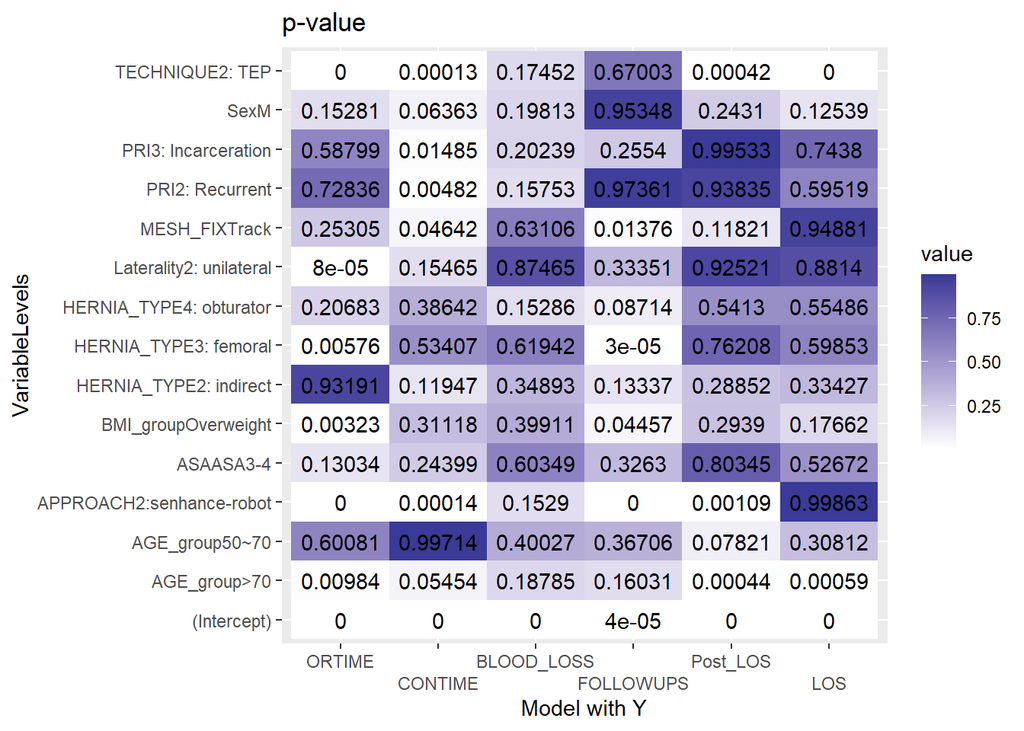

### coefficients

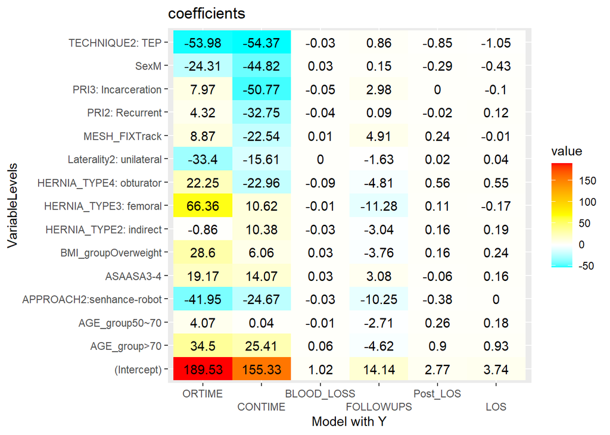

# **5 Conclusion**

Using `svyglm` (linear model) to compare **“robot”** with **“senhance-robot”**, it is found that patients with the **“senhance-robot”** have shorter operation times than those with the **“robot”**. Operation time, console time, and the days from surgery to discharge are affected by the different approaches.